# QMM 1002_CASE STUDY 1_INEMESIT UDOKANG_A00271891

2024-04-19

## Introduction

I have been collecting data and keeping track of my daily activities for some time. The data was collected from two different semesters: the first semester and the second semester. The dates range from October 31, 2023, to April 16, 2024.

The variables in the personalized data set are as follows:

| Variable | Type |
| --- | --- |
| Date | Identifier |
| Zoom (hours) | Quantitative |
| Study (hours) | Quantitative |
| Sleep (hours) | Quantitative |
| Tea | Quantitative |
| Twitter feed (news feed) | Categorical |
| Daily exercise(activity performed) | Categorical |
| Daily task achievement (scale of 1-5 | Categorical |
| Time spent listening to music (hours) | Quantitative |
| Semester (First & Second) | Categorical |

This information will provide me with enough information to study my habits and better understand my lifestyle. The major goal of this case study is to answer the below questions;

- What do you do in a day?
- Do you spend your days how you expect?
- Is any difference in how you spend your time this semester compared to last semester?

**Summary Statistics**

The variables that will be analyzed are hours spent studying, hours sleeping, and hours spent listening to music during the period.

```
##  Time.spent.listening.to.music..hrs.   Study.hrs.      Sleep.hrs.
##  Min.   :1.000                       Min.   :0.000   Min.   :3.000
##  1st Qu.:1.000                       1st Qu.:2.000   1st Qu.:5.000
##  Median :2.000                       Median :3.000   Median :6.000
##  Mean   :2.246                       Mean   :3.008   Mean   :6.189
##  3rd Qu.:3.000                       3rd Qu.:4.000   3rd Qu.:7.625
##  Max.   :6.000                       Max.   :7.000   Max.   :8.500
```

```
## [1] "Standard deviation for Studying:"
```

```
## [1] 1.558019
```

```
## [1] "Standard deviation for sleeping:"
```

```
## [1] 1.531514
```

```
## [1] "Standard deviation for music:"
```

```
## [1] 1.259311
```

Summary statistics for the variables:

1. Mean and standard deviation for the hours spent studying variable: Mean = 3.008, Standard Deviation = 1.558019.
2. Mean and standard deviation for the hours spent sleeping variable: Mean = 6.189, Standard Deviation = 1.531514.
3. Mean and standard deviation for Time spent listening to music (hours) variable: Mean = 2.246, Standard Deviation = 1.259311.

**Checking the four conditions required for using the t-distribution for each variable:**

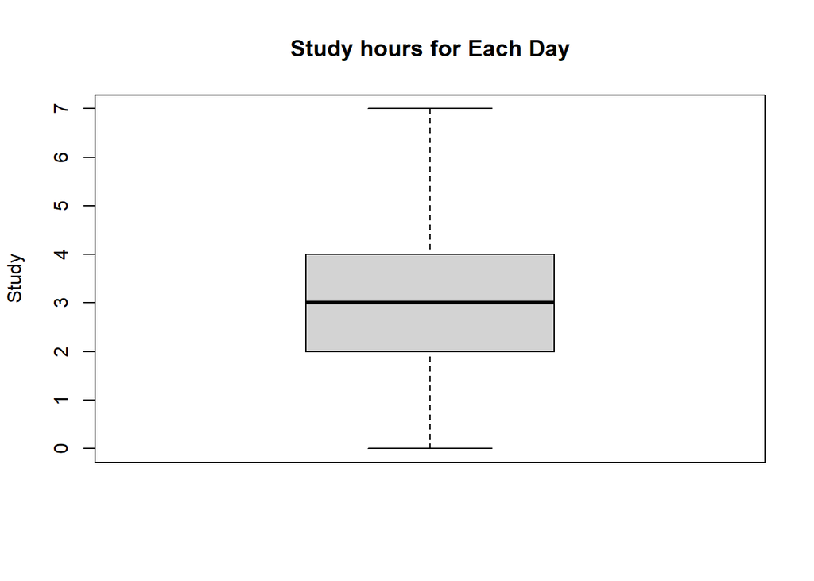

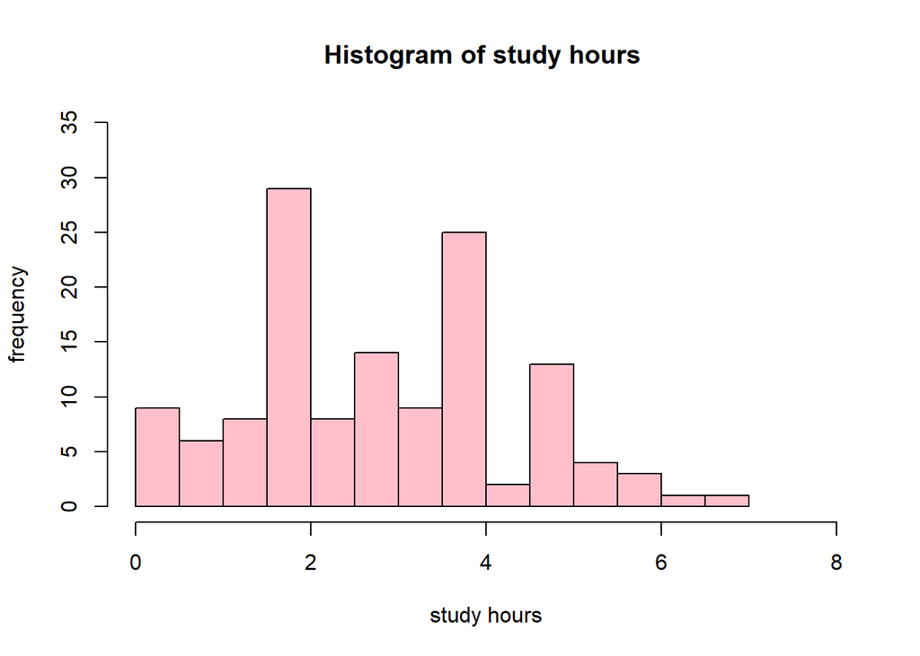

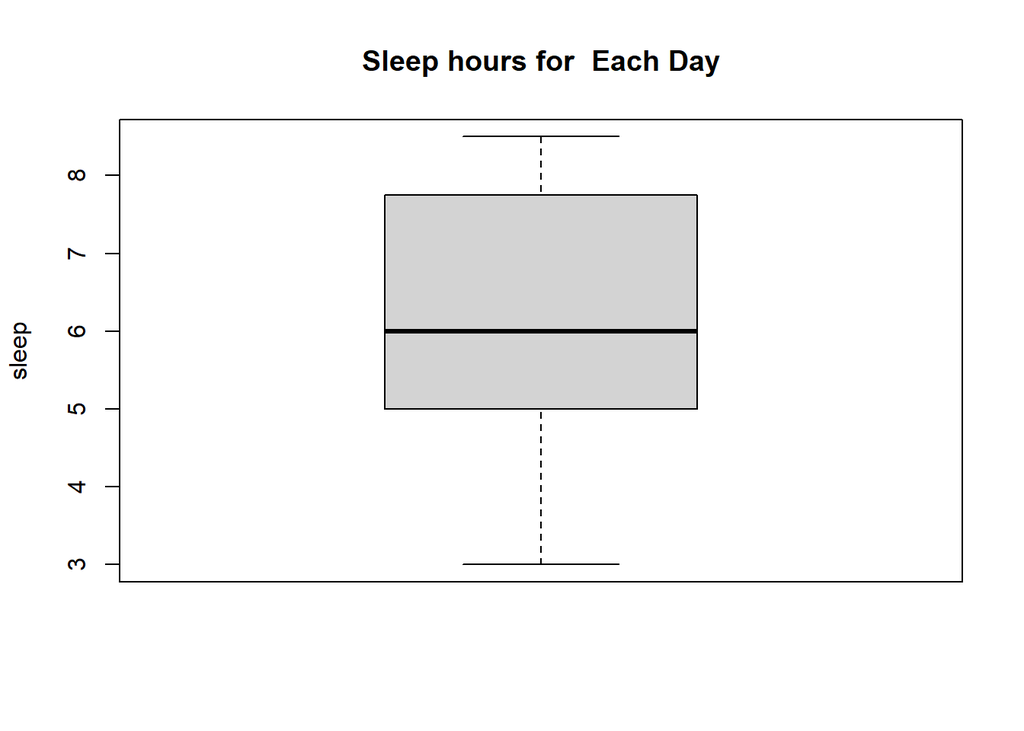

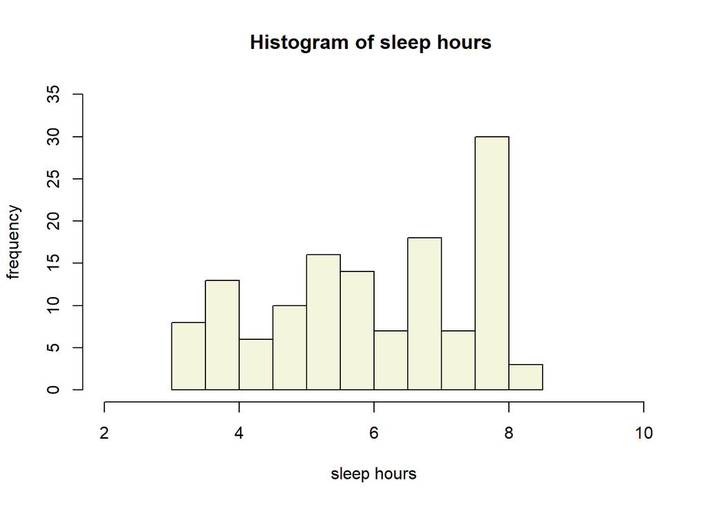

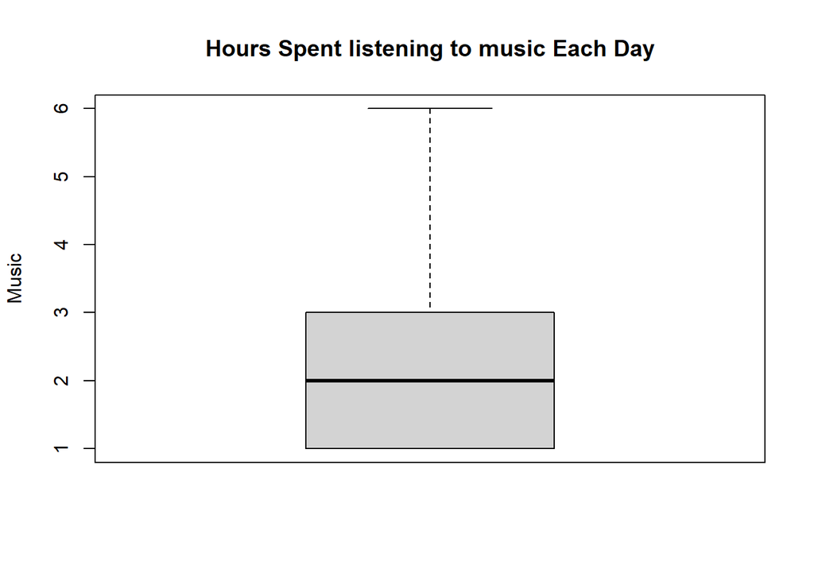

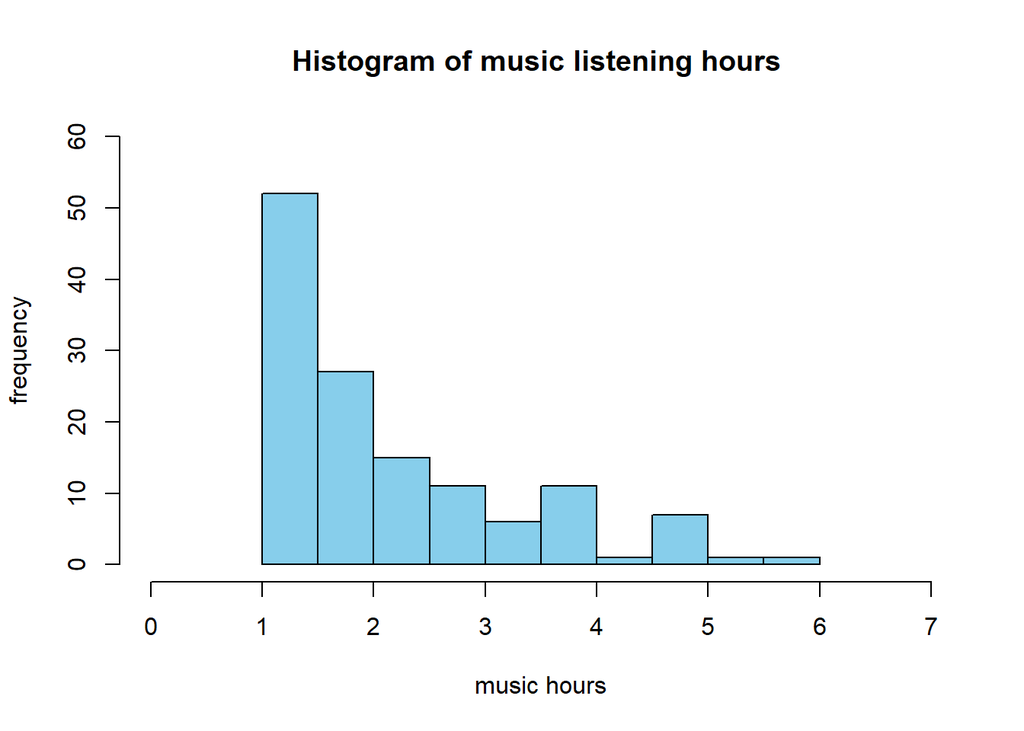

This histogram above represents my music listening hours over time. It is unimodal but not normally distributed. On the other hand, the boxplot does not represent any outliers.